# Coursework Report

*N* removed NAs: 3

*N* removed typo: 1

*N* removed <18: 21

*N* total clean: 125

| Group | *N* | *M*<sub>age</sub> | *M*<sub>rating</sub> |
| --- | --- | --- | --- |
| Control | 55 | 21.04 | 5.45 |
| Experim | 70 | 20.46 | 5.73 |

**Main analysis results**

*t*(123) = -1.93, *p* = .055

[interactive chart not shown]

[figure not shown]

[interactive chart not shown]

# Coursework Report

Analysing Data, Spring 2020

# Methods

## Participants

This study was carried out on a sample of 117 participants (*M*<sub>age</sub> = 21.11, *SD*<sub>age</sub> = 1.84). However, data from 8 volunteers was removed because of unlikely age values. Therefore, the final results included 109 participants.

Table 1 *Descriptive statistics by categories of condition*

| CONDITION | *N* | % | *M*<sub>age</sub> | *SD*<sub>Age</sub> |
| --- | --- | --- | --- | --- |
| control | 51 | 46.79 | 21.27 | 1.94 |
| experimental | 58 | 53.21 | 20.97 | 1.76 |

## Design

The study aimed to test the hypothesis that the colour red increases women’s attraction to males. Subjects viewed a photo of an averagely attractive younger Caucasian male for 5 seconds, which was black and white, on either a white background (control condition) or red background (experimental condition). Following this they gave their opinion of the male’s attractiveness.

Attractiveness was a numeric variable and was measured with 3 different questions using a 9-point scale. The questions were as follows; “How attractive do you think this person is?”, “How pleasant is this person to look at?” and “If I were to meet the person in this picture face to face, I would think he is attractive.”. The 9-point scale was numeric and ranged from 1 (not at all attractive) to 9 (extremely attractive).

We will investigate whether, as hypothesised, women will rate their attractiveness to the photo of the male differently dependent on the background colour by using an independent-measures *t*-test.

# Results

As discussed we tested whether women’s attractiveness ratings of men differed depending on the background colour of the male’s photo, using an independent-measures *t*-test. The analysis highlighted that, as hypothesised, the male in front of a red background was given higher mean ratings (*M* = 5.7) by the female participants, than the male in front of a white background (*M* = 5.44).

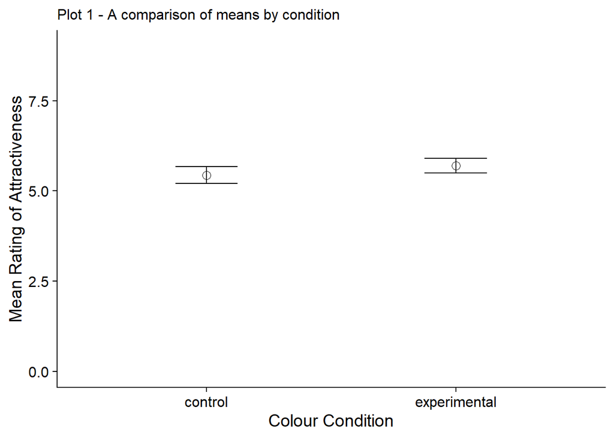

However the difference in means was not actually significant (*M*<sub>diff</sub> = -0.26, 95% CI [-0.58, 0.05], *t* (107) = -1.67, *p* = 0.099), therefore we must accept the null hypothesis.

To summarise, the results from our statistical analysis emphasise that whether or not a participant viewed the male on a white or red background, there is no influence on their ratings of the male’s attractiveness.

# Discussion

Our results show, contrary from our hypothesis, that the colour red had no effect on females’ attractiveness towards men.

These findings are different from previous studies. For example one study found that women who saw a male in a red shirt, instead of a blue shirt, rated him as more attractive (Elliot, A. J., Kayser, D. N., Greitemeyer, T., Lichtenfeld, S., Gramzow, R. H., Maier, M. A., & Liu, H., 2010). It is important to note these participants were unaware of the effect of colour on their ratings of attractiveness (Elliot, A. J., Kayser, D. N., Greitemeyer, T., Lichtenfeld, S., Gramzow, R. H., Maier, M. A., & Liu, H., 2010).

Despite the fact our findings were not in line with our original hypothesis, this does not mean there is no causal relationship between the colour red and male attractiveness to women. The experimental method, which was used in this research, has traditionally been the most effective way to demonstrate causal relationships (Breakwell, G., Hammond, S., Fife-Schaw, C., Smith, J., 2006). The experimental nature of our research means in theory it should have been able to underline a causal relationship between attractiveness in men in conjunction with the colour red as this was our only independent variable between both conditions (Breakwell, G., Hammond, S., Fife-Schaw, C., Smith, J., 2006). However, as our results were not as predicted, it is possible that some factors, which were non-accounted for, influenced attractiveness ratings. Such factors may include the male’s clothing or hairstyle (Breakwell, G., Hammond, S., Fife-Schaw, C., Smith, J., 2006). Another factor that may have effected results is the participants themselves. It is important we have a wide range of participants to ensure the study is representative.

Research that supports our hypothesis, indicating that the colour red heightens female attraction to men, would be very useful within the advertising and marketing sector (Lin, 2014) as it may be applicable to advertise products using more red aspects.

To summarise, this paper found that, unlike similar research from the literature, women do not necessarily find men more attractive in conjunction with the colour red. However, it important to maintain that our results may not be valid nor representative due to possible unaccounted for variables (Breakwell, G., Hammond, S., Fife-Schaw, C., Smith, J., 2006) or a bias subject sample. It is important that future research continues to study the effect that red makes men more attractive to women due to its possible uses in industries such as advertising and marketing (Lin, 2014).

# References

Breakwell, G., Hammond, S., Fife-Schaw, C., Smith, J., (2006), *Research Methods in Psychology*, (3rd ed.), London, SAGE Publications Ltd

Elliot, A. J., Kayser, D. N., Greitemeyer, T., Lichtenfeld, S., Gramzow, R. H., Maier, M. A., & Liu, H. (2010). Red, rank, and romance in women viewing men, *Journal of Experimental Psychology: General*, *139*(3), 399–417

Lin, H., (2014), Red coloured products enhance the attractiveness of women, *Displays*, *35*(4), 202-205